# BUDT758X

- Assignment #5
- Instructor: Prof. Sean Barnes
- Studnet: Xukun(Frank) LIU (https://www.xukun-liu.com)
- Topics: Data Processing, GroupBy Mechanics, & Time Series Data Analysis
- Data/Code:
- Exercise #1
  - Exercise #1.a.
  - Exercise #1.b.
  - Exercise #1.c.
- Exercise #2
  - Exercise #2.a.
  - Exercise #2.b.
  - Exercise #2.c.
  - Exercise #2.d.
  - Exercise #2.e.

Socially responsible investing (SRI) is a strategy that targets companies that promote ethical practices, environmental stewardship, and social justice. It draws inspiration from various periods in U.S. history, including the establishment of Quakerism (1700s) and the Civil Rights Movement (1960s). In recent years, the availability of socially responsible mutual funds and exchange-traded funds (ETFs) have facilitated easy and diversified investments consistent with various socially responsible values (e.g., clean energy, gender diversity). In this assignment, you will perform processing and analysis on a selection of 82 socially responsible ETFs identified by ETF.com  
Preview the document. The data contains information on the

- ticker (stock symbol),
- fund name,
- issuer,
- total assets under management (AUM),
- expense ration,
- 30-day trailing return,
- and market segment of each ETF.

## Exercise #1 (5 points)

### 1.a. (3 points)

Import the ETF data into a data frame using an appropriate method, and complete the following processing tasks:

- Ensure all missing values are explicitly represented by numpy.nan
- Ensure all numerical columns are represented by appropriate numerical types (i.e., integer or floating point values)
- Separate the elements of the SEGMENT column into distinct columns:
  - (Asset) Class: Equity or Fixed Income
  - Market: U.S., China, Developed Markets, Emerging Markets, etc.
  - Segment: Total Market, Large Cap, Small Cap, Renewable Energy, etc.
- Index the data frame by ISSUER and TICKER, and sort the data frame lexicographically (i.e., by ISSUER and then TICKER).
- Display the full data frame as proof of your processing.

```python
import os
import pandas as pd
import numpy as np
import matplotlib.pyplot as plt
import re
```

```python
os.getcwd()
```

```
'/Users/xukunliu/Google Drive (xukun.liu@rhsmith.umd.edu)/RHSmith-Sync/2-Spring-2019/1-BUDT 758X (0502)/Assignment/Assignment#5'
```

```python
os.listdir()
```

```
['Icon\r',
 'BUDT758X_Assignment#5_XukunLIU.html',
 'socially_responsible_etfs.xlsx',
 'BUDT758X_Assignment#5_XukunLIU.ipynb',
 '.ipynb_checkpoints']
```

**1.a.1. Import the ETF data into a data frame using an appropriate method**

```python
dt = pd.read_excel('socially_responsible_etfs.xlsx')
```

**1.a.2. Ensure all missing values are explicitly represented by numpy.nan**

```python
dt.head()
```

|  | TICKER | FUND NAME | ISSUER | AUM | EXPENSE RATIO | 3-MO TR | SEGMENT |
| --- | --- | --- | --- | --- | --- | --- | --- |
| 0 | DSI | iShares MSCI KLD 400 Social ETF | BlackRock | $1.31B | 0.0025 | 0.0678 | Equity: U.S. - Total Market |
| 1 | SUSA | iShares MSCI U.S.A. ESG Select ETF | BlackRock | $905.59M | 0.0025 | 0.0673 | Equity: U.S. - Total Market |
| 2 | USSG | Xtrackers MSCI U.S.A. ESG Leaders Equity ETF | Deutsche Bank | $856.18M | 0.0010 | -- | Equity: U.S. - Total Market |
| 3 | ESGD | iShares ESG MSCI EAFE ETF | BlackRock | $643.78M | 0.0020 | 0.0571 | Equity: Developed Markets Ex-U.S. - Total Market |
| 4 | ESGE | iShares ESG MSCI EM ETF | BlackRock | $503.64M | 0.0025 | 0.0807 | Equity: Emerging Markets - Total Market |

```python
dt.isnull().sum()
```

```
TICKER           0
FUND NAME        0
ISSUER           0
AUM              0
EXPENSE RATIO    0
3-MO TR          0
SEGMENT          0
dtype: int64
```

```python
dt.isna().sum()
```

```
TICKER           0
FUND NAME        0
ISSUER           0
AUM              0
EXPENSE RATIO    0
3-MO TR          0
SEGMENT          0
dtype: int64
```

```python
dt.isin(['--']).sum()
```

```
TICKER           0
FUND NAME        0
ISSUER           0
AUM              0
EXPENSE RATIO    0
3-MO TR          1
SEGMENT          0
dtype: int64
```

**comments: seems '--' representing misssing value**

```python
dt.loc[dt['3-MO TR']=='--',['3-MO TR']] = np.NaN
```

```python
dt.isnull().sum()
```

```
TICKER           0
FUND NAME        0
ISSUER           0
AUM              0
EXPENSE RATIO    0
3-MO TR          1
SEGMENT          0
dtype: int64
```

**1.a.3 Ensure all numerical columns are represented by appropriate numerical types (i.e., integer or floating point values)**

```python
def AUM_trans(s):
    patt='\d*\.\d*'
    m=re.search(patt,s)
    if s[-1]=='B':
        return float(m.group())*1000
    else:
        return float(m.group())
```

```python
AUM_trans('$1.31B')
```

```
1310.0
```

```python
dt['AUM'] = dt['AUM'].apply(lambda x: AUM_trans(x))
```

```python
dt['EXPENSE RATIO']=dt['EXPENSE RATIO'].astype('float')
```

```python
dt['3-MO TR'] = dt['3-MO TR'].astype('float')
```

```python
dt.head()
```

|  | TICKER | FUND NAME | ISSUER | AUM | EXPENSE RATIO | 3-MO TR | SEGMENT |
| --- | --- | --- | --- | --- | --- | --- | --- |
| 0 | DSI | iShares MSCI KLD 400 Social ETF | BlackRock | 1310.00 | 0.0025 | 0.0678 | Equity: U.S. - Total Market |
| 1 | SUSA | iShares MSCI U.S.A. ESG Select ETF | BlackRock | 905.59 | 0.0025 | 0.0673 | Equity: U.S. - Total Market |
| 2 | USSG | Xtrackers MSCI U.S.A. ESG Leaders Equity ETF | Deutsche Bank | 856.18 | 0.0010 | NaN | Equity: U.S. - Total Market |
| 3 | ESGD | iShares ESG MSCI EAFE ETF | BlackRock | 643.78 | 0.0020 | 0.0571 | Equity: Developed Markets Ex-U.S. - Total Market |
| 4 | ESGE | iShares ESG MSCI EM ETF | BlackRock | 503.64 | 0.0025 | 0.0807 | Equity: Emerging Markets - Total Market |

```python
dt.dtypes
```

```
TICKER            object
FUND NAME         object
ISSUER            object
AUM              float64
EXPENSE RATIO    float64
3-MO TR          float64
SEGMENT           object
dtype: object
```

**1.a.4. Separate the elements of the SEGMENT column into distinct columns:**

- (Asset) Class: Equity or Fixed Income
- Market: U.S., China, Developed Markets, Emerging Markets, etc.
- Segment: Total Market, Large Cap, Small Cap, Renewable Energy, etc.

```python
# we could split the string with more than one delimiter
def segment_split(s):
    patt='\: | - '
    m=re.split(patt,s)
    return m
```

```python
segment_split('Equity: U.S. - Total Market')
```

```
['Equity', 'U.S.', 'Total Market']
```

```python
# before we apply this method, check is all the data have the same format
sum(dt['SEGMENT'].apply(lambda x: len(segment_split(x)))!=3)
```

```
13
```

```python
dt.loc[dt['SEGMENT'].apply(lambda x: len(segment_split(x)))!=3,'SEGMENT']
```

```
7     Equity: Global Renewable Energy
13    Equity: Global Renewable Energy
15         Equity: Global Environment
17    Equity: Global Renewable Energy
23    Equity: Global Renewable Energy
24    Equity: Global Renewable Energy
25    Equity: Global Renewable Energy
41    Equity: Global Renewable Energy
50         Equity: Global Environment
51    Equity: Global Renewable Energy
61    Equity: Global Renewable Energy
71               Equity: Global Water
76    Equity: Global Renewable Energy
Name: SEGMENT, dtype: object
```

```python
# fix them and make sure all the format are the same
# '\' stands for newline
dt.loc[dt['SEGMENT'].apply(lambda x: len(segment_split(x)))!=3,'SEGMENT'] \
=dt.loc[dt['SEGMENT'].apply(lambda x: len(segment_split(x)))!=3,'SEGMENT'].apply(lambda x: x.replace('Global','Global -'))
```

```python
sum(dt['SEGMENT'].apply(lambda x: len(segment_split(x)))!=3)
```

```
0
```

```python
dt['CLASS'] = dt['SEGMENT'].apply(lambda x: segment_split(x)[0])
dt['MKT'] = dt['SEGMENT'].apply(lambda x: segment_split(x)[1])
dt['SEG'] = dt['SEGMENT'].apply(lambda x: segment_split(x)[2])
```

```python
dt = dt.drop(columns=['SEGMENT'])
```

**1.a.5. Index the data frame by ISSUER and TICKER, and sort the data frame lexicographically (i.e., by ISSUER and then TICKER).**

```python
dt = dt.set_index(keys=['ISSUER','TICKER']).sort_index(level=[0,1])
dt.head(10)
```

| ISSUER | TICKER | FUND NAME | AUM | EXPENSE RATIO | 3-MO TR | CLASS | MKT | SEG |
| --- | --- | --- | --- | --- | --- | --- | --- | --- |
| Barclays Bank PLC | RODI | Barclays Return on Disability ETN | 38.70 | 0.0045 | 0.0000 | Equity | U.S. | Total Market |
|  | WIL | Barclays Women in Leadership ETN | 38.14 | 0.0045 | 0.0762 | Equity | U.S. | Total Market |
| BlackRock | BGRN | iShares Global Green Bond ETF | 25.90 | 0.0020 | 0.0320 | Fixed Income | Global | Broad Market, Broad-based Investment Grade |
|  | CRBN | iShares MSCI ACWI Low Carbon Target ETF | 411.69 | 0.0020 | 0.0670 | Equity | Global | Total Market |
|  | DSI | iShares MSCI KLD 400 Social ETF | 1310.00 | 0.0025 | 0.0678 | Equity | U.S. | Total Market |
|  | EAGG | iShares ESG U.S. Aggregate Bond ETF | 56.45 | 0.0010 | 0.0281 | Fixed Income | U.S. | Broad Market, Broad-based Investment Grade |
|  | ESGD | iShares ESG MSCI EAFE ETF | 643.78 | 0.0020 | 0.0571 | Equity | Developed Markets Ex-U.S. | Total Market |
|  | ESGE | iShares ESG MSCI EM ETF | 503.64 | 0.0025 | 0.0807 | Equity | Emerging Markets | Total Market |
|  | ESGU | iShares ESG MSCI U.S.A. ETF | 174.29 | 0.0015 | 0.0540 | Equity | U.S. | Total Market |
|  | ESML | iShares ESG MSCI U.S.A. Small-Cap ETF | 22.35 | 0.0017 | 0.0825 | Equity | U.S. | Small Cap |

**1.a.6 Display the full data frame as proof of your processing.**

```python
pd.set_option('display.max_columns', dt.shape[1])
pd.set_option('display.max_rows', dt.shape[0])
dt
```

| ISSUER | TICKER | FUND NAME | AUM | EXPENSE RATIO | 3-MO TR | CLASS | MKT | SEG |
| --- | --- | --- | --- | --- | --- | --- | --- | --- |
| Barclays Bank PLC | RODI | Barclays Return on Disability ETN | 38.70 | 0.0045 | 0.0000 | Equity | U.S. | Total Market |
|  | WIL | Barclays Women in Leadership ETN | 38.14 | 0.0045 | 0.0762 | Equity | U.S. | Total Market |
| BlackRock | BGRN | iShares Global Green Bond ETF | 25.90 | 0.0020 | 0.0320 | Fixed Income | Global | Broad Market, Broad-based Investment Grade |
|  | CRBN | iShares MSCI ACWI Low Carbon Target ETF | 411.69 | 0.0020 | 0.0670 | Equity | Global | Total Market |
|  | DSI | iShares MSCI KLD 400 Social ETF | 1310.00 | 0.0025 | 0.0678 | Equity | U.S. | Total Market |
|  | EAGG | iShares ESG U.S. Aggregate Bond ETF | 56.45 | 0.0010 | 0.0281 | Fixed Income | U.S. | Broad Market, Broad-based Investment Grade |
|  | ESGD | iShares ESG MSCI EAFE ETF | 643.78 | 0.0020 | 0.0571 | Equity | Developed Markets Ex-U.S. | Total Market |
|  | ESGE | iShares ESG MSCI EM ETF | 503.64 | 0.0025 | 0.0807 | Equity | Emerging Markets | Total Market |
|  | ESGU | iShares ESG MSCI U.S.A. ETF | 174.29 | 0.0015 | 0.0540 | Equity | U.S. | Total Market |
|  | ESML | iShares ESG MSCI U.S.A. Small-Cap ETF | 22.35 | 0.0017 | 0.0825 | Equity | U.S. | Small Cap |
|  | ICLN | iShares Global Clean Energy ETF | 202.27 | 0.0047 | 0.1199 | Equity | Global | Renewable Energy |
|  | SDG | iShares MSCI Global Impact ETF | 45.76 | 0.0049 | 0.0596 | Equity | Global | Total Market |
|  | SUSA | iShares MSCI U.S.A. ESG Select ETF | 905.59 | 0.0025 | 0.0673 | Equity | U.S. | Total Market |
|  | SUSB | iShares ESG 1-5 Year USD Corporate Bond ETF | 70.48 | 0.0012 | 0.0256 | Fixed Income | U.S. | Corporate, Broad-based Investment Grade Short-... |
|  | SUSC | iShares ESG USD Corporate Bond ETF | 25.57 | 0.0018 | 0.0421 | Fixed Income | U.S. | Corporate, Broad-based Investment Grade |
| Change Finance | CHGX | Change Finance U.S. Large Cap Fossil Fuel Free... | 6.02 | 0.0049 | 0.0667 | Equity | U.S. | Large Cap |
| Columbia | ESGN | Columbia Sustainable International Equity Inco... | 6.31 | 0.0045 | 0.0491 | Equity | Developed Markets Ex-U.S. | Total Market |
|  | ESGS | Columbia Sustainable U.S. Equity Income ETF | 4.06 | 0.0035 | 0.0486 | Equity | U.S. | Total Market |
|  | ESGW | Columbia Sustainable Global Equity Income ETF | 18.08 | 0.0040 | 0.0511 | Equity | Developed Markets | Total Market |
| Deutsche Bank | ACSG | Xtrackers MSCI ACWI ex U.S.A. ESG Leaders Equi... | 7.68 | 0.0016 | 0.0567 | Equity | Global Ex-U.S. | Total Market |
|  | EASG | Xtrackers MSCI EAFE ESG Leaders Equity ETF | 7.19 | 0.0014 | 0.0486 | Equity | Developed Markets Ex-U.S. | Total Market |
|  | EMSG | Xtrackers MSCI Emerging Markets ESG Leaders Eq... | 7.71 | 0.0020 | 0.0681 | Equity | Emerging Markets | Total Market |
|  | USSG | Xtrackers MSCI U.S.A. ESG Leaders Equity ETF | 856.18 | 0.0010 | NaN | Equity | U.S. | Total Market |
| ETF Managers Group | ETHO | Etho Climate Leadership U.S. ETF | 44.06 | 0.0045 | 0.0872 | Equity | U.S. | Total Market |
| First Trust | FAN | First Trust Global Wind Energy ETF | 72.39 | 0.0060 | 0.1094 | Equity | Global | Renewable Energy |
|  | QCLN | First Trust NASDAQ Clean Edge Green Energy Ind... | 97.50 | 0.0060 | 0.0928 | Equity | Global | Renewable Energy |
| Goldman Sachs | JUST | Goldman Sachs JUST U.S. Large Cap Equity ETF | 111.14 | 0.0020 | 0.0556 | Equity | U.S. | Large Cap |
| Impact Shares | NACP | Impact Shares NAACP Minority Empowerment ETF | 2.12 | 0.0076 | 0.0622 | Equity | U.S. | Total Market |
|  | SDGA | Impact Shares Sustainable Development Goals Gl... | 1.98 | 0.0076 | 0.0431 | Equity | Global | Total Market |
|  | WOMN | Impact Shares YWCA Women's Empowerment ETF | 3.92 | 0.0076 | 0.0548 | Equity | U.S. | Total Market |

[output cut: 52 more lines]

### 1.b. (1 point)

- Select a socially responsible ETF of your choosing, and research the motivation and strategy behind the SRI.
- Write (in your own words) a sufficiently detailed description that explains this information, and list a few of the top holdings (companies) that provide additional context about the strategy (i.e., which companies operate in a manner consistent with the values of the investment).

Etho Climate Leadership U.S. ETF(ETHO.US)

- ETHO is one the the first diversified index ETF, which anchored ECLI (Etho Climate Leadership Index U.S.)
- The investment goal of ETHO ETF is providing the holders with return (before fee and other expense) similarly to the price and yield result of ECLI
- ECLI is an index focusing/tracing on the the companies who has the best climent friendly policies and industry performance within their market segments
- According to the data pulled on Apr 7, 2018:
  - ETHO mainly focusing on common stock issed in United States 96.67%
  - Holdings (By industry):
    - Information Technology: 22.17%
    - Industry: 18.31%
    - Financial Service: 13.03%
    - Consumer discretionary: 11.99%
    - Health: 11.52%
    - Raw material: 5.54%
    - Public Service: 4.46%
    - Real Estate: 3.82%，
    - Communication: 3.30%，
    - Essential consumer goods: 3.15%
    - Others
  - Holdings (By Company)(Top10):
    - Cash & Equivalent - 1.10%
    - AMD - 0.73%
    - DXCM - 0.63%
    - XLNX - 0.55%
    - LULU - 0.54%
    - KEYS - 0.53%
    - IDTI - 0.51%
    - ions - 0.51%
    - MSEX - 0.51%
    - NGVT - 0.50%
    - ULTA - 0.50%

### 1.c. (1 point)

- Given your processed ETF data, formulate an interesting question about socially responsible ETFs.
- Then, perform the appropriate analysis needed to address the question and describe your results.
- You will be evaluated on both the quality of your question and the quality of your analysis and description.

**Question #1: For each company, what is the total amount of asset under management?**

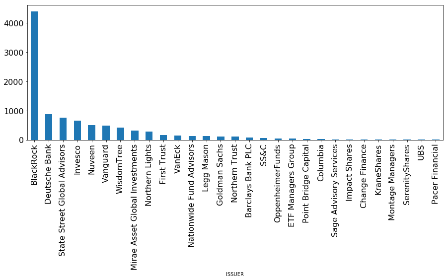

```python
dt['AUM'].groupby('ISSUER').sum().sort_values(ascending=False).plot.bar(figsize=(15,5),rot=90,fontsize=16)
```

**Question #2: Is there any relationship between the AUM and Expense ratio?**

- Higher AUM lead to higher Expense ratio?

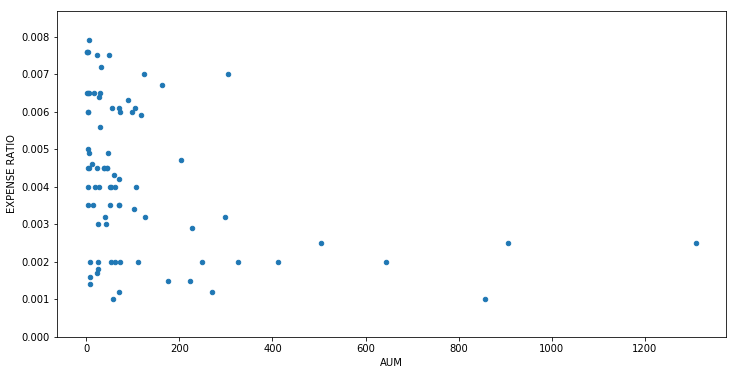

```python
dt.plot.scatter(x='AUM',y='EXPENSE RATIO',figsize=(12,6),ylim=(0,dt['EXPENSE RATIO'].max()*1.1))
```

**Question #3: Is there any relationship between the EXPENSE RATIO and 3-MO TR?**

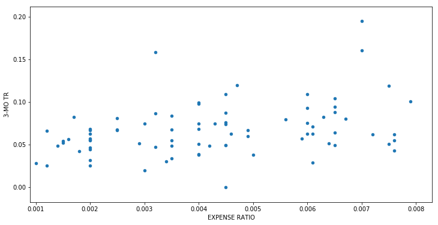

```python
dt.plot.scatter(x='EXPENSE RATIO',y='3-MO TR',figsize=(12,6),xlim=(dt['EXPENSE RATIO'].min()*0.9,dt['EXPENSE RATIO'].max()*1.05))
```

## Exercise #2 (5 points)

For this part of the assignment, you will need to install the pandas-datareader package, which is a separate package from pandas that facilitates importation of financial and economic data directly into pandas data structures. The easiest way to install (it is not available within the Anaconda distribution) is via pip (from your command prompt):

pip install pandas-datareader

If pip is not a recognizable command, you can try 'conda install pip' and see if that solves your problem. Otherwise, let me know and we can explore additional installation solutions.

Additional installation details are found at: https://github.com/pydata/pandas-datareader (Links to an external site.)

Package documentation is found at: http://pandas-datareader.readthedocs.io/en/latest/remote_data.html (Links to an external site.)

### 2.a. (1 point)

- Set up your code by specifying the ticker of a socially responsible ETF (your choice) as a string assigned to a variable.
- Use the pandas-datareader to extract historical price (open, high, low, and close)
- and trading volume of your selected ETF from the Yahoo API (see documentation),
- which should date as far back as Jan. 1, 2010, depending on the age of the ETF (some are quite new).
- Preview the first 10 rows of the resulting data frame.

```python
import pandas_datareader as pdr
import datetime
```

```python
startDate = datetime.date(year=2010,month=1,day=1)
endDate = datetime.date(year=2019,month=4,day=7)
ETF_ID = 'ETHO'
etho = pdr.data.get_data_yahoo(symbols=ETF_ID,start=startDate,end=endDate)
```

```python
etho.head(10)
# earlies data available on 2015-11-19
```

| Date | High | Low | Open | Close | Volume | Adj Close |
| --- | --- | --- | --- | --- | --- | --- |
| 2015-11-19 | 25.030001 | 24.969999 | 25.030001 | 24.980000 | 6600.0 | 24.179768 |
| 2015-11-20 | 25.370001 | 25.090000 | 25.370001 | 25.100000 | 8400.0 | 24.295921 |
| 2015-11-23 | 25.370001 | 25.100000 | 25.370001 | 25.139999 | 6800.0 | 24.334633 |
| 2015-11-24 | 25.270000 | 25.000000 | 25.120001 | 25.270000 | 2700.0 | 24.460474 |
| 2015-11-25 | 25.309999 | 25.240000 | 25.250000 | 25.309999 | 2700.0 | 24.499193 |
| 2015-11-27 | 25.360001 | 25.330000 | 25.330000 | 25.350000 | 11800.0 | 24.537916 |
| 2015-11-30 | 25.690001 | 25.243999 | 25.690001 | 25.250000 | 20900.0 | 24.441116 |
| 2015-12-01 | 25.440001 | 25.330000 | 25.330000 | 25.426001 | 800.0 | 24.611481 |
| 2015-12-02 | 25.520000 | 25.250000 | 25.520000 | 25.250000 | 5300.0 | 24.441116 |
| 2015-12-03 | 25.420000 | 24.820000 | 25.420000 | 24.830000 | 15900.0 | 24.034569 |

### 2.b. (1 point)

- Report the ETF information (i.e., price and trading volume data) from December 28, 2018, the last trading day of the year,
  - which marked the end of a significant (negative) correction in the financial markets.
- Then, report the ETF information from 75 days later (March 13, 2019).
- Calculate the percent difference in the closing stock price (relative to December 28, 2018), and report the percent difference in a formatted string in the form of:
  - The closing price of [Ticker] has changed by [Percent Difference]% between [December 28, 2018] and [75 days later].
- where the entries in brackets represent variables that you will specify/calculate along the way.
- This format will facilitate reporting a similar analysis for other stock tickers.
- You may output the dates in any reasonable format.

**2.b.1 Report the ETF information (i.e., price and trading volume data) from December 28, 2018, the last trading day of the year,**

- which marked the end of a significant (negative) correction in the financial markets.

```python
etho_Dec_28_2018 = etho.loc['2018-12-28',:]
etho_Dec_28_2018
```

```
High           32.105000
Low            31.632999
Open           31.912001
Close          31.708000
Volume       6700.000000
Adj Close      31.590816
Name: 2018-12-28 00:00:00, dtype: float64
```

**2.b.2 Then, report the ETF information from 75 days later (March 13, 2019).**

```python
gap = datetime.timedelta(days=75)
```

```python
etho_Mar_13_2019 = etho.loc[datetime.date(2018,12,28)+gap,:]
etho_Mar_13_2019
```

```
High           37.139999
Low            36.984001
Open           37.020000
Close          36.984001
Volume       1700.000000
Adj Close      36.847321
Name: 2019-03-13 00:00:00, dtype: float64
```

```python
perc_diff = (etho_Mar_13_2019/etho_Dec_28_2018-1)*100
perc_diff
```

```
High         15.682915
Low          16.915885
Open         16.006517
Close        16.639337
Volume      -74.626866
Adj Close    16.639342
dtype: float64
```

```python
etho_Dec_28_2018.name.strftime('%a,%b-%d-%Y')
```

```
'Fri,Dec-28-2018'
```

```python
report_str = 'The closing price of {} has changed by {}% between {} and {}.'
report_str = report_str.format('ETHO',round(perc_diff['Close'],2),etho_Dec_28_2018.name.strftime('%a,%b-%d-%Y'),\
                               etho_Mar_13_2019.name.strftime('%a,%b-%d-%Y'))
print(report_str)
```

```
The closing price of ETHO has changed by 16.64% between Fri,Dec-28-2018 and Wed,Mar-13-2019.
```

### 2.c. (1 point)

- Define a function plot_price that will visualize the complete time series of a specified price column (i.e., Open, High, Low, or Close) over a specified period.
  - The function should take in the full ETF data frame and a price argument that specifies the type of price (as a string) that you want to visualize.
  - The period should be defined using separate arguments (start, end) that can be input to the function in any date format appropriate for slicing time series data.
  - The start and end arguments should each have None as default values, which signifies that you should include all of the data from the beginning (if start=None) and the end (if end=None) of the date range for the data in the default case.
  - The visualization should be of the appropriate type for time series data, and the x- and y-axes should be appropriately labeled.
  - Demonstrate the performance of your function on the Close price of your selected ETF for the full date range and (separately) for the last year.
  - Provide a brief description of the price history (full date range and over the last year) of your selected ETF.

```python
def plot_price(data,price_type,start=None,end=None):
    data.loc[start:end,[price_type]].plot(figsize=(15,5)).set(xlabel="Date", ylabel=price_type)
```

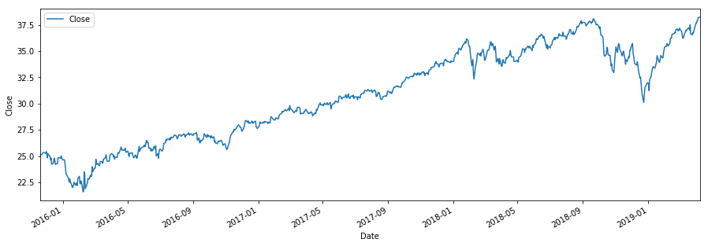

```python
plot_price(data=etho,price_type='Close')
```

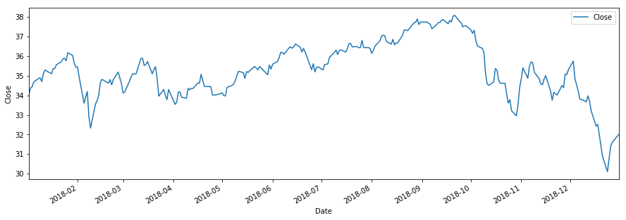

```python
plot_price(data=etho,price_type='Close',start='20180101',end='20181231')
```

### 2.d. (1 point)

- Modify your plot_price function (plot_price2) to visualize an optional simple moving average (SMA) and/or an optional exponentially weighted moving average (EWMA), along with the specified price column (still over a specified date range).
- The SMA argument (sma) should be set to None in the default case, but is specified as an integer over which the SMA is calculated (e.g., a 30-day SMA would be specified as sma=30).
- The argument for the exponentially weighted moving average (ewma) should be implemented in a similar manner.
- Each moving average should be overlaid with the price on a similar visualization as for part c, which should include appropriate axis labels as well as a legend that differentiates each visualized time series.
- Demonstrate the performance of your function on the Close price of your selected ETF for the last year, and provide an explanation about how each moving average captures the behavior of the ETF price.

```python
def plot_price2(data,price_type,start=None,end=None,sma=None,ewma=None):
    data = data.loc[start:end,[price_type]]
    data.plot(figsize=(15,5)).set(xlabel="Date", ylabel=price_type)
    legend=[price_type]
    if sma!=None:
        data['SMA'] = data[price_type].rolling(sma).mean()
        data['SMA'].plot(figsize=(15,5))
        data['SMA_expand'] = data[price_type].expanding(sma).mean()
        data['SMA_expand'].plot(figsize=(15,5))
        legend.append('SMA-Rolling')
        legend.append('SMA-Expanding')
    if ewma!=None:
        data['EWMA'] = data[price_type].ewm(span=ewma).mean()
        data['EWMA'].plot(figsize=(15,5))
        legend.append('EWMA')
        plt.legend(tuple(legend))
```

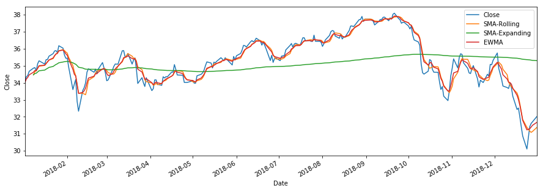

```python
plot_price2(etho,'Close','2018-01-01','2018-12-31',sma=5,ewma=5)
```

### 2.e. (1 point)

- Define a function plot_volume that visualizes the trend in aggregate trading volume over a downsampled period.
- The function should take in the historical price data frame for your selected ETF and a frequency argument (freq) similar to those defined in Table 11-4 in the text.
- The function should sum the total trading volume over the specified time period, which should be less frequent than the daily data that you have extracted from Yahoo (e.g., monthly, quarterly, annually).
- The visualization should be of the appropriate type for this data, and the y-axis should be appropriately labeled (the x-axis should be in an appropriate datetime format and does not need to be labeled).
- Demonstrate the performance of your function on the quarterly volume of your selected ETF for the full date range.
- Provide a brief description of any trends that you observe in the aggregated trading volume of your selected ETF.

```python
def plot_volume(data,freq,start=None,end=None,):
    if freq not in ['W','M','Q','A']:
        print("Error: Please choose a frequency from: 'W','M','Q','A'")
        return None
    data.loc[start:end,'Volume'].resample(freq).sum().plot(kind = 'bar',figsize=(15,5),color='Orange',rot=45)\
    .set(xlabel="Date", ylabel='Vol')
    plt.legend(('Total Trading Volume',))
```

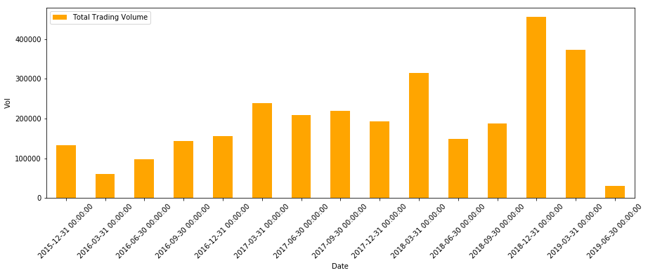

```python
plot_volume(data=etho,freq='Q')
```

- B business day frequency
- C custom business day frequency (experimental)
- D calendar day frequency
- W weekly frequency
- M month end frequency
- SM semi-month end frequency (15th and end of month)
- BM business month end frequency
- CBM custom business month end frequency
- MS month start frequency
- SMS semi-month start frequency (1st and 15th)
- BMS business month start frequency
- CBMS custom business month start frequency
- Q quarter end frequency
- BQ business quarter endfrequency
- QS quarter start frequency
- BQS business quarter start frequency
- A year end frequency
- BA, BY business year end frequency
- AS, YS year start frequency
- BAS, BYS business year start frequency
- BH business hour frequency
- H hourly frequency
- T, min minutely frequency
- S secondly frequency
- L, ms milliseconds
- U microseconds
- N, us nanoseconds